# Analiza danych Tesco

## Modele

### Wyniki Analizy Regresji Liniowej Oceny Wpływu Sprzedaży i Rabatów na Procentowy Zysk w Tesco.

| term | estimate | std.error | statistic | p.value |
| --- | --- | --- | --- | --- |
| (Intercept) | 42.941 | 0.308 | 139.408 | 0 |
| I(Sales/100) | -0.157 | 0.038 | -4.166 | 0 |
| Discount | -1.956 | 0.011 | -172.078 | 0 |

| r.squared | adj.r.squared | sigma | statistic | p.value | df | logLik | AIC | BIC | deviance | df.residual | nobs |
| --- | --- | --- | --- | --- | --- | --- | --- | --- | --- | --- | --- |
| 0.748 | 0.748 | 23.446 | 14805.61 | 0 | 2 | -45707.62 | 91423.24 | 91452.08 | 5492398 | 9991 | 9994 |

Model regresji liniowej bada wpływ sprzedaży i wysokości udzielanych rabatów na procentowy zysk. Co istotne, każdy wzrost sprzedaży o 100 jednostek jest związany ze średnim spadkiem procentowego zysku o około 0.1568 punktu procentowego. Natomiast, zwiększenie rabatu o jeden punkt procentowy wiąże się ze średnim spadkiem procentowego zysku o 1.9557 punktu procentowego.

Współczynnik determinacji R-kwadrat wynosi około 0.7477, co oznacza, że około 74.77% zmienności procentowego zysku jest wyjaśnione przez te dwa predyktory. Jeśli chodzi o negatywny związek między sprzedażą a procentowym zyskiem to możliwe, że przy większych ilościach sprzedaży firma sprzedaje produkty z niższą marżą, które przyczyniają się do wzrostu obrotów, ale niekoniecznie do wzrostu zysków procentowych.

### Wykres punktowy modelu regresji liniowej

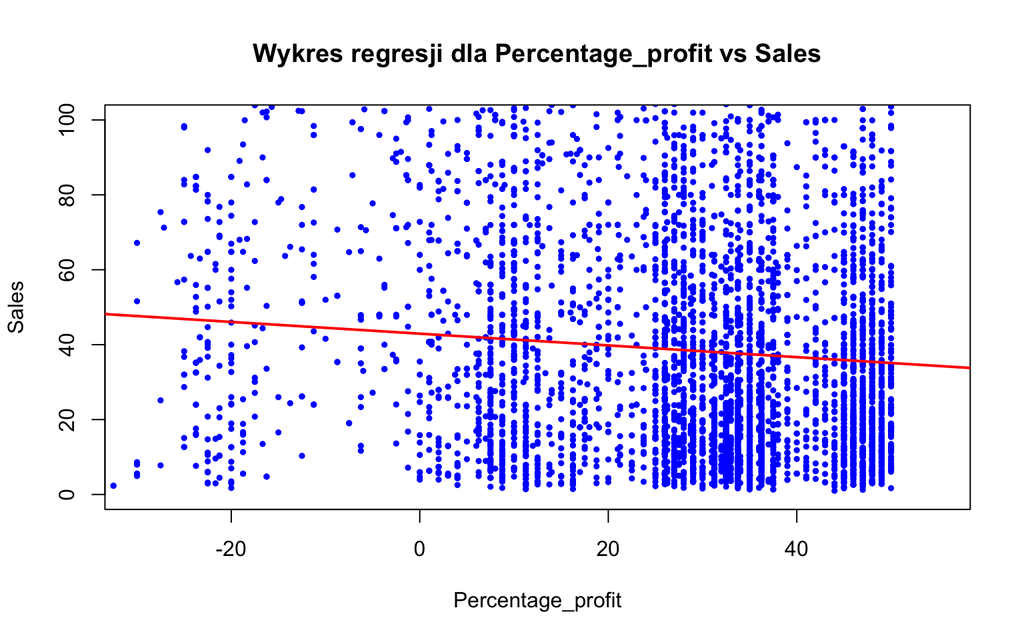

Wykres przedstawia rozproszenie danych punktowych ilustrujących związek między procentowym zyskiem (Percentage_profit) a sprzedażą (Sales). Kropki reprezentują pojedyncze transakcje. Czerwona linia na wykresie reprezentuje linię regresji, która pokazuje ogólny trend w danych.

| term | estimate | std.error | statistic | p.value |
| --- | --- | --- | --- | --- |
| (Intercept) | 41.926 | 0.526 | 79.689 | 0 |
| Average_Percentage_discount | -1.897 | 0.016 | -120.363 | 0 |
| Total_quantity | -0.174 | 0.048 | -3.655 | 0 |

| r.squared | adj.r.squared | sigma | statistic | p.value | df | logLik | AIC | BIC | deviance | df.residual | nobs |
| --- | --- | --- | --- | --- | --- | --- | --- | --- | --- | --- | --- |
| 0.743 | 0.743 | 20.932 | 7248.402 | 0 | 2 | -22339.62 | 44687.24 | 44713.32 | 2193277 | 5006 | 5009 |

Model regresji liniowej analizuje wpływ średniego procentowego rabatu i całkowitej ilości sprzedanych produktów na średni procentowy zysk. Zgodnie z modelem, każde zwiększenie średniego procentowego rabatu o jeden punkt procentowy dla zamówienia jest powiązane ze średnim spadkiem średniego procentowego zysku z zamówienia o około 1.8970 punktu procentowego. Ponadto, wzrost ilości sprzedanych produktów w zamówieniu o jedną jednostkę średnio wiąże się ze spadkiem średniego procentowego zysku o 0.1738 punktu procentowego. Współczynnik determinacji R-kwadrat modelu wynosi 0.7433, co oznacza, że około 74.33% zmienności średniego procentowego zysku jest wyjaśnione przez te dwie zmienne. Ujemny związek między całkowitą ilością a średnim procentowym zyskiem może sugerować, że zwiększone ilości sprzedaży powodują że sklep ma niższą marżę dla dużych zamówień i wykorzystuje tu efekt dużego wolumenu, co może przyczyniać się do wzrostu sprzedaży ogólnej, lecz niekoniecznie zwiększać zysk procentowy.